# Le,Cody-DSC540-ProjectML

## Predicting Patient Stay Days (Length of Stay in Hospital): Classification Models for Imbalanced Target Variable

## Introduction

This analysis focuses on predicting Patients' Length of Stay (LOS) during the COVID-19 Pandemic. The COVID-19 pandemic overloaded hospital care resources and efficient resource management and allocation are vital to stablizing the healthcare system. The objective of this analysis is to develop machine learning models to predict LOS to help improve resource allocation since LOS is an important indiactor for monitoring health management processes.

**Goals of Analysis:**

```
- Perform a thorough Exploratory Data Analysis (EDA), clean, and transform the data <br>
- Split data into training, validation, and testing <br>
- Build baseline models for classification of target variables, Stay Days (Hospital Length of Stay) <br>
- Optimize classifiers that performed well from baseline models <br>
- Peform additional model optimization <br>
- Implement multiclass learning models <br>
- Implement voting ensemble models <br>
- Evaluate the best performing models on the test set <br>
- Review final results and future analysis <br>
```

## Data Pre-Processing

### Load Packages

```python
import pandas as pd
import numpy as np
import matplotlib.pyplot as plt
import seaborn as sns

from sklearn import metrics
from sklearn.metrics import accuracy_score, balanced_accuracy_score, classification_report
from sklearn.preprocessing import LabelEncoder
from sklearn.preprocessing import MinMaxScaler
from sklearn.model_selection import train_test_split
from sklearn.model_selection import cross_val_score
from sklearn.model_selection import GridSearchCV
from sklearn.ensemble import RandomForestClassifier
from sklearn.ensemble import AdaBoostClassifier
from sklearn.ensemble import GradientBoostingClassifier
from sklearn.ensemble import HistGradientBoostingClassifier
from sklearn.ensemble import VotingClassifier
from sklearn.svm import SVC
from sklearn.svm import LinearSVC
from sklearn.discriminant_analysis import LinearDiscriminantAnalysis
from sklearn.discriminant_analysis import QuadraticDiscriminantAnalysis
from sklearn.neighbors import KNeighborsClassifier
from sklearn.linear_model import SGDClassifier
from sklearn.multiclass import OneVsRestClassifier
from sklearn.multiclass import OneVsOneClassifier
```

```python
import warnings
warnings.filterwarnings('ignore') #ignore warnings

# set display max columns
pd.set_option('display.max_columns', 100)
```

### Data Description

```python
# View Data Dictionary:
hos_data_dic = pd.read_csv('hospital_los_data_dic.csv')
hos_data_dic
```

|  | Column | Description |
| --- | --- | --- |
| 0 | case_id | Case_ID registered in Hospital |
| 1 | Hospital_code | Unique code for the Hospital |
| 2 | Hospital_type_code | Unique code for the type of Hospital |
| 3 | City_Code_Hospital | City Code of the Hospital |
| 4 | Hospital_region_code | Region Code of the Hospital |
| 5 | Available Extra Rooms in Hospital | Number of Extra rooms available in the Hospital |
| 6 | Department | Department overlooking the case |
| 7 | Ward_Type | Code for the Ward type |
| 8 | Ward_Facility_Code | Code for the Ward Facility |
| 9 | Bed Grade | Condition of Bed in the Ward |
| 10 | patientid | Unique Patient Id |
| 11 | City_Code_Patient | City Code for the patient |
| 12 | Type of Admission | Admission Type registered by the Hospital |
| 13 | Severity of Illness | Severity of the illness recorded at the time o... |
| 14 | Visitors with Patient | Number of Visitors with the patient |
| 15 | Age | Age of the patient |
| 16 | Admission_Deposit | Deposit at the Admission Time |
| 17 | Stay | Stay Days by the patient |

The dataset contains 18 columns with the description of each column indicated above.

### Data Quality and Data Types

```python
# Read and Display Dataset:
hos = pd.read_csv('hospital_los.csv')
hos
```

|  | case_id | Hospital | Hospital_type | Hospital_city | Hospital_region | Available_Extra_Rooms_in_Hospital | Department | Ward_Type | Ward_Facility | Bed_Grade | patientid | City_Code_Patient | Type of Admission | Illness_Severity | Patient_Visitors | Age | Admission_Deposit | Stay_Days |
| --- | --- | --- | --- | --- | --- | --- | --- | --- | --- | --- | --- | --- | --- | --- | --- | --- | --- | --- |
| 0 | 1 | 8 | 2 | 3 | 2 | 3 | radiotherapy | R | F | 2.0 | 31397 | 7.0 | Emergency | Extreme | 2 | 51-60 | 4911.0 | 0-10 |
| 1 | 2 | 2 | 2 | 5 | 2 | 2 | radiotherapy | S | F | 2.0 | 31397 | 7.0 | Trauma | Extreme | 2 | 51-60 | 5954.0 | 41-50 |
| 2 | 3 | 10 | 4 | 1 | 0 | 2 | anesthesia | S | E | 2.0 | 31397 | 7.0 | Trauma | Extreme | 2 | 51-60 | 4745.0 | 31-40 |
| 3 | 4 | 26 | 1 | 2 | 1 | 2 | radiotherapy | R | D | 2.0 | 31397 | 7.0 | Trauma | Extreme | 2 | 51-60 | 7272.0 | 41-50 |
| 4 | 5 | 26 | 1 | 2 | 1 | 2 | radiotherapy | S | D | 2.0 | 31397 | 7.0 | Trauma | Extreme | 2 | 51-60 | 5558.0 | 41-50 |
| ... | ... | ... | ... | ... | ... | ... | ... | ... | ... | ... | ... | ... | ... | ... | ... | ... | ... | ... |
| 318433 | 318434 | 6 | 0 | 6 | 0 | 3 | radiotherapy | Q | F | 4.0 | 86499 | 23.0 | Emergency | Moderate | 3 | 41-50 | 4144.0 | 11-20 |
| 318434 | 318435 | 24 | 0 | 1 | 0 | 2 | anesthesia | Q | E | 4.0 | 325 | 8.0 | Urgent | Moderate | 4 | 81-90 | 6699.0 | 31-40 |
| 318435 | 318436 | 7 | 0 | 4 | 0 | 3 | gynecology | R | F | 4.0 | 125235 | 10.0 | Emergency | Minor | 3 | 71-80 | 4235.0 | 11-20 |
| 318436 | 318437 | 11 | 1 | 2 | 1 | 3 | anesthesia | Q | D | 3.0 | 91081 | 8.0 | Trauma | Minor | 5 | 11-20 | 3761.0 | 11-20 |
| 318437 | 318438 | 19 | 0 | 7 | 1 | 5 | gynecology | Q | C | 2.0 | 21641 | 8.0 | Emergency | Minor | 2 | 11-20 | 4752.0 | 0-10 |

318438 rows × 18 columns

```python
# Check data types and data quality:
hos.info()
```

```
<class 'pandas.core.frame.DataFrame'>
RangeIndex: 318438 entries, 0 to 318437
Data columns (total 18 columns):
 #   Column                             Non-Null Count   Dtype
---  ------                             --------------   -----
 0   case_id                            318438 non-null  int64
 1   Hospital                           318438 non-null  int64
 2   Hospital_type                      318438 non-null  int64
 3   Hospital_city                      318438 non-null  int64
 4   Hospital_region                    318438 non-null  int64
 5   Available_Extra_Rooms_in_Hospital  318438 non-null  int64
 6   Department                         318438 non-null  object
 7   Ward_Type                          318438 non-null  object
 8   Ward_Facility                      318438 non-null  object
 9   Bed_Grade                          318325 non-null  float64
 10  patientid                          318438 non-null  int64
 11  City_Code_Patient                  313906 non-null  float64
 12  Type of Admission                  318438 non-null  object
 13  Illness_Severity                   318438 non-null  object
 14  Patient_Visitors                   318438 non-null  int64
 15  Age                                318438 non-null  object
 16  Admission_Deposit                  318438 non-null  float64
 17  Stay_Days                          318438 non-null  object
dtypes: float64(3), int64(8), object(7)
memory usage: 43.7+ MB
```

```python
# Find Number of Missing Values for Each Variable:
hos.isnull().sum()
```

```
case_id                                 0
Hospital                                0
Hospital_type                           0
Hospital_city                           0
Hospital_region                         0
Available_Extra_Rooms_in_Hospital       0
Department                              0
Ward_Type                               0
Ward_Facility                           0
Bed_Grade                             113
patientid                               0
City_Code_Patient                    4532
Type of Admission                       0
Illness_Severity                        0
Patient_Visitors                        0
Age                                     0
Admission_Deposit                       0
Stay_Days                               0
dtype: int64
```

The dataset has missing values for Bed_Grade and City_Code_Patient. Since these are unique values and the size of the dataset is quite large at over 300,000 entries, the missing values will be removed for this analysis.

```python
# Remove All Missing Values:
hos_df = hos.dropna()
hos_df.isnull().sum() #recheck missing values
```

```
case_id                              0
Hospital                             0
Hospital_type                        0
Hospital_city                        0
Hospital_region                      0
Available_Extra_Rooms_in_Hospital    0
Department                           0
Ward_Type                            0
Ward_Facility                        0
Bed_Grade                            0
patientid                            0
City_Code_Patient                    0
Type of Admission                    0
Illness_Severity                     0
Patient_Visitors                     0
Age                                  0
Admission_Deposit                    0
Stay_Days                            0
dtype: int64
```

```python
# Recheck Data Types and Quality:
hos_df.info()
```

```
<class 'pandas.core.frame.DataFrame'>
Int64Index: 313793 entries, 0 to 318437
Data columns (total 18 columns):
 #   Column                             Non-Null Count   Dtype
---  ------                             --------------   -----
 0   case_id                            313793 non-null  int64
 1   Hospital                           313793 non-null  int64
 2   Hospital_type                      313793 non-null  int64
 3   Hospital_city                      313793 non-null  int64
 4   Hospital_region                    313793 non-null  int64
 5   Available_Extra_Rooms_in_Hospital  313793 non-null  int64
 6   Department                         313793 non-null  object
 7   Ward_Type                          313793 non-null  object
 8   Ward_Facility                      313793 non-null  object
 9   Bed_Grade                          313793 non-null  float64
 10  patientid                          313793 non-null  int64
 11  City_Code_Patient                  313793 non-null  float64
 12  Type of Admission                  313793 non-null  object
 13  Illness_Severity                   313793 non-null  object
 14  Patient_Visitors                   313793 non-null  int64
 15  Age                                313793 non-null  object
 16  Admission_Deposit                  313793 non-null  float64
 17  Stay_Days                          313793 non-null  object
dtypes: float64(3), int64(8), object(7)
memory usage: 45.5+ MB
```

```python
# Summary Statistics:
hos_df.describe()
```

|  | case_id | Hospital | Hospital_type | Hospital_city | Hospital_region | Available_Extra_Rooms_in_Hospital | Bed_Grade | patientid | City_Code_Patient | Patient_Visitors | Admission_Deposit |
| --- | --- | --- | --- | --- | --- | --- | --- | --- | --- | --- | --- |
| count | 313793.000000 | 313793.000000 | 313793.000000 | 313793.000000 | 313793.000000 | 313793.000000 | 313793.000000 | 313793.000000 | 313793.000000 | 313793.000000 | 313793.000000 |
| mean | 158937.911120 | 18.326419 | 1.257781 | 4.778169 | 0.780358 | 3.196419 | 2.622952 | 65743.029382 | 7.252447 | 3.280857 | 4881.893165 |
| std | 91939.506976 | 8.633613 | 1.535338 | 3.103237 | 0.752329 | 1.167924 | 0.872618 | 37978.083237 | 4.745243 | 1.761758 | 1086.243945 |
| min | 1.000000 | 1.000000 | 0.000000 | 1.000000 | 0.000000 | 0.000000 | 1.000000 | 1.000000 | 1.000000 | 0.000000 | 1800.000000 |
| 25% | 79271.000000 | 11.000000 | 0.000000 | 2.000000 | 0.000000 | 2.000000 | 2.000000 | 32833.000000 | 4.000000 | 2.000000 | 4188.000000 |
| 50% | 158950.000000 | 19.000000 | 1.000000 | 5.000000 | 1.000000 | 3.000000 | 3.000000 | 65735.000000 | 8.000000 | 3.000000 | 4742.000000 |
| 75% | 238399.000000 | 26.000000 | 2.000000 | 7.000000 | 1.000000 | 4.000000 | 3.000000 | 98472.000000 | 8.000000 | 4.000000 | 5410.000000 |
| max | 318438.000000 | 32.000000 | 6.000000 | 13.000000 | 2.000000 | 24.000000 | 4.000000 | 131624.000000 | 38.000000 | 32.000000 | 11008.000000 |

From the summary statistics, we can see that there appears to be outliers for Available_Extra_Rooms_in_Hospital, City_Code_Patient, and Patient_Visitors since the max is way more than 3 times the IQR for these features. We will confirm the presence of outliers by plotting the distribution of each feature.

### Exploratory Data Analysis

#### Distribution of Numeric Features

First, we will examine the distribution and relationship of the numeric features through histogram and boxplots. The following numeric features will be examined: Hosptial, Hospital_type, Hospital_city, Hospital_region, Available_Extra_Rooms_in_Hospital, Bed_Grade, City_Code_Patient, Patient_Visitors, Admission_Deposit. There are a total of 9 features with numeric data type.

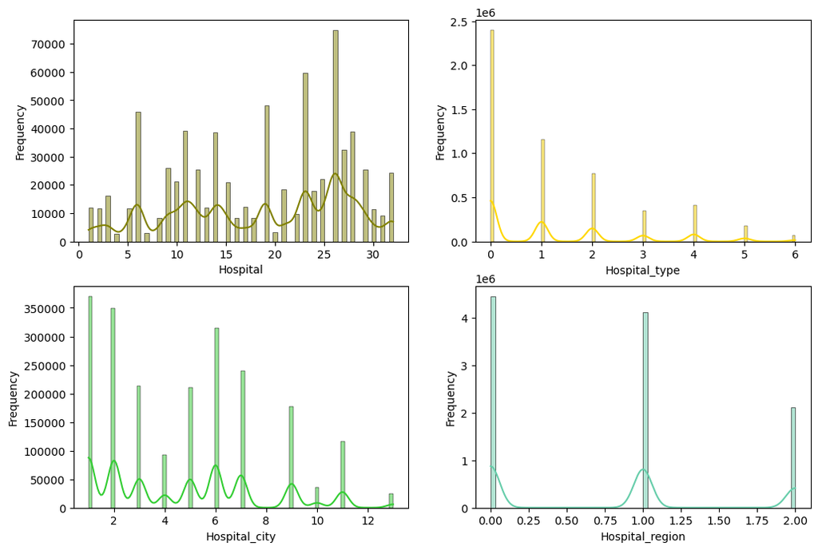

```python
# Check distributions for numeric features:
fig, axes = plt.subplots(2, 2, figsize=(12, 8))

sns.histplot(hos_df, x='Hospital', kde=True, color='olive', stat='frequency', ax=axes[0,0])
sns.histplot(hos_df, x='Hospital_type', kde=True, color='gold', stat='frequency', ax=axes[0,1])
sns.histplot(hos_df, x='Hospital_city', kde=True, color='limegreen', stat='frequency', ax=axes[1,0])
sns.histplot(hos_df, x='Hospital_region', kde=True, color='mediumaquamarine', stat='frequency', ax=axes[1,1])
plt.show()
```

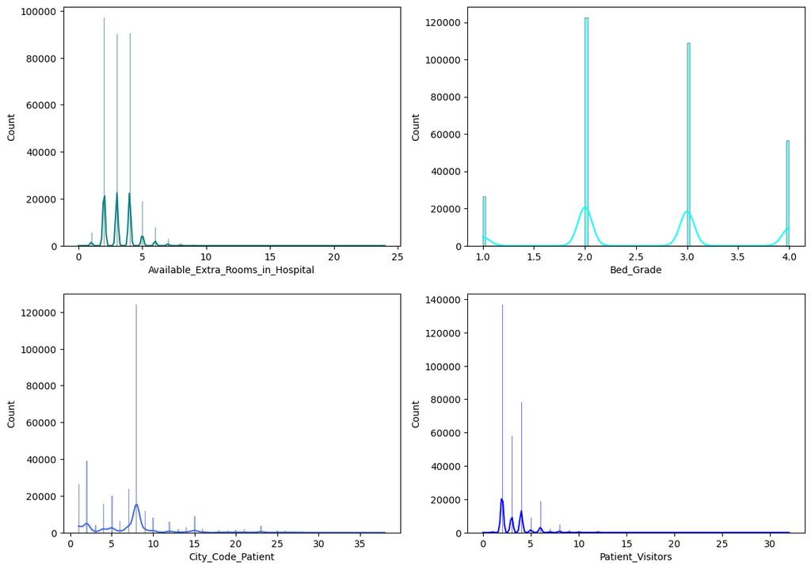

```python
# Check distribution for numeric features:
fig, axes = plt.subplots(2, 2, figsize=(14, 10))

sns.histplot(hos_df, x='Available_Extra_Rooms_in_Hospital', kde=True, color='teal', ax=axes[0,0])
sns.histplot(hos_df, x='Bed_Grade', kde=True, color='aqua', ax=axes[0,1])
sns.histplot(hos_df, x='City_Code_Patient', kde=True, color='royalblue', ax=axes[1,0])
sns.histplot(hos_df, x='Patient_Visitors', kde=True, color='blue', ax=axes[1,1])
plt.show()
```

Above, features such as Available_Extra_Rooms_in_Hospital, City_Code_Patient, and Patient_Visitors have outliers. For Available_Extra_Rooms_in_Hospital the outliers appear to occur after 7, whereas for City_Code_Patient the outliers occur around 15, and for Patient_Visitors the outliers occur around 7. The boxplots for the features below confirm the presence of outliers.

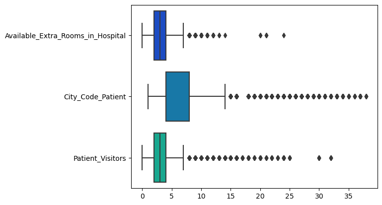

```python
# Boxplots showing outliers for Available_Extra_Rooms_in_Hospital, City_Code_Patient, & Patient_Visitors:
sns.boxplot(data=hos_df[['Available_Extra_Rooms_in_Hospital', 'City_Code_Patient', 'Patient_Visitors']],
            orient="h", palette='winter')
plt.show()
```

```python
# Number of observations suspected as outliers for Available_Extra_Rooms_in_Hospital:
count1 = (hos_df['Available_Extra_Rooms_in_Hospital'] > 7).sum()
count1
```

```
1336
```

```python
# Number of observations suspected as outliers for City_Code_Patient:
count2 = (hos_df['City_Code_Patient'] > 15).sum()
count2
```

```
15827
```

```python
# Number of observations suspected as outliers for Patient_Visitors:
count2 = (hos_df['Patient_Visitors'] > 7).sum()
count2
```

```
9612
```

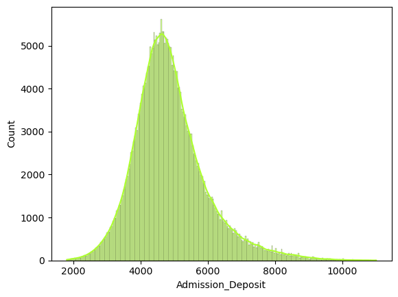

```python
# Check distribution for Admission_Deposit:
sns.histplot(hos_df, x='Admission_Deposit', kde=True, color='greenyellow')
plt.show()
```

#### Distribution of Categorical Features

Next, we will examine the distribution and relationship of the categorical features through countplots. The following categorical features will be examined: Department, Ward_Type, Ward_Facility, Type of Admission, Illness_Severity, Age, and Stay_Days. There are a total of 7 categorical features including the target variable, Stay_Days.

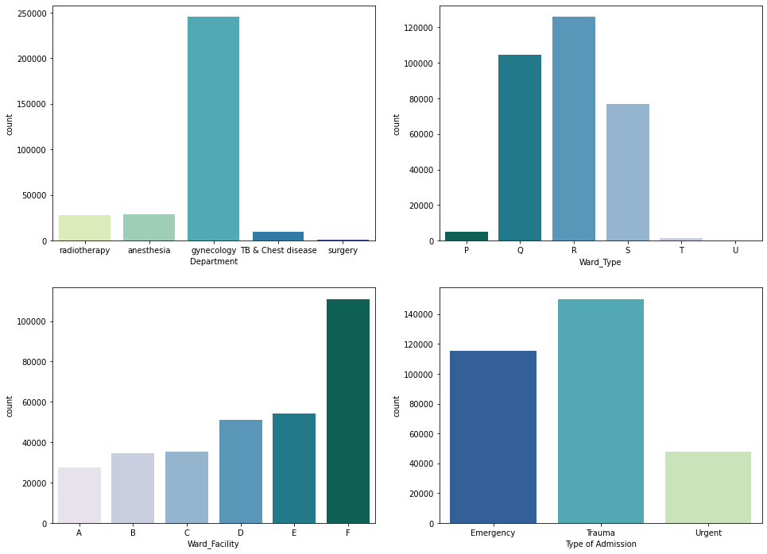

```python
# Check distributions for categorical features:
ward_order = ['P', 'Q', 'R', 'S', 'T', 'U'] #order for Ward_Type
wfac_order = ['A', 'B', 'C', 'D', 'E', 'F'] #order for Ward_Facility
fig, axes = plt.subplots(2, 2, figsize=(16, 12)) # set fig size

sns.countplot(x=hos_df['Department'], palette='YlGnBu', ax=axes[0,0]) #plot Department
sns.countplot(x=hos_df['Ward_Type'], order=ward_order, palette='PuBuGn_r', ax=axes[0,1]) #plot by order
sns.countplot(x=hos_df['Ward_Facility'], order=wfac_order, palette='PuBuGn', ax=axes[1,0]) #plot by order
sns.countplot(x=hos_df['Type of Admission'], palette='YlGnBu_r', ax=axes[1,1]) #plot Type of Admission
plt.show()
```

```python
# Value Counts for Department:
hos_df['Department'].value_counts()
```

```
gynecology            245850
anesthesia             29187
radiotherapy           28153
TB & Chest disease      9460
surgery                 1143
Name: Department, dtype: int64
```

```python
# Proportion of each value for Department:
round(hos_df['Department'].value_counts(normalize=True) *100,2)
```

```
gynecology            78.35
anesthesia             9.30
radiotherapy           8.97
TB & Chest disease     3.01
surgery                0.36
Name: Department, dtype: float64
```

Above, the distribution for Ward_Type, Ward_Facility, and Type of Admission do not exhibit any abonormalities. However, the distribution for Department is highly skewed. Over 78% of the values are for the Gynecology department. This imbalance in distribution may affect the model later on. For this analysis, all instances for Department will remain in the analysis.

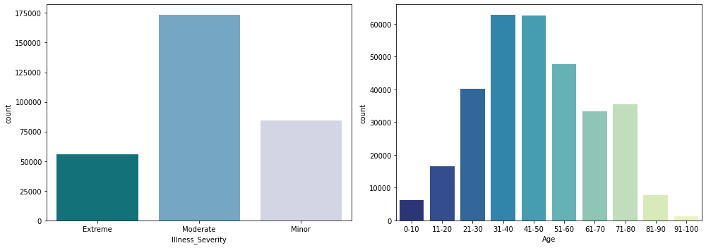

```python
# Check distributions for Illness_Severity and Age:
# Order for Age
age_order = ['0-10', '11-20', '21-30', '31-40', '41-50', '51-60', '61-70', '71-80', '81-90', '91-100']
fig, axes = plt.subplots(1, 2, figsize=(14, 5)) # set fig size

sns.countplot(x=hos_df['Illness_Severity'], palette='PuBuGn_r', ax=axes[0]) #plot for Illness_Severity
sns.countplot(x=hos_df['Age'], order=age_order, palette='YlGnBu_r', ax=axes[1]) #plot for Age by Order
plt.tight_layout()
plt.show()
```

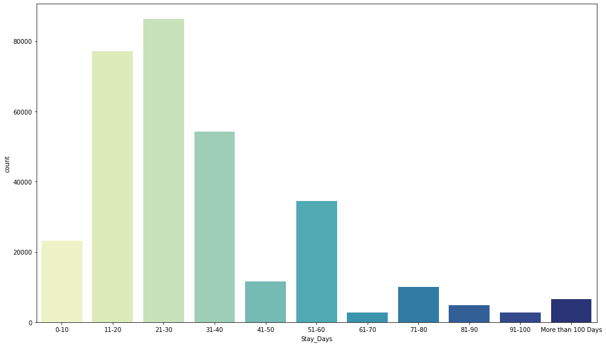

```python
# Check distribution for Stay_Days:
stay_order = ['0-10', '11-20', '21-30', '31-40', '41-50', '51-60', '61-70', '71-80', '81-90', '91-100', 'More than 100 Days']
fig = plt.figure(figsize=(14, 8)) #above, order for stay_days, set fig size
sns.countplot(x=hos_df['Stay_Days'], order=stay_order, palette='YlGnBu') #plot based on order
plt.tight_layout()
plt.show()
```

```python
# Value Counts for Stay_Days:
hos_df['Stay_Days'].value_counts()
```

```
21-30                 86316
11-20                 77095
31-40                 54312
51-60                 34463
0-10                  23250
41-50                 11541
71-80                 10096
More than 100 Days     6548
81-90                  4761
91-100                 2713
61-70                  2698
Name: Stay_Days, dtype: int64
```

```python
# Proportion of each class for Stay_Days:
round(hos_df['Stay_Days'].value_counts(normalize=True) *100,2)
```

```
21-30                 27.51
11-20                 24.57
31-40                 17.31
51-60                 10.98
0-10                   7.41
41-50                  3.68
71-80                  3.22
More than 100 Days     2.09
81-90                  1.52
91-100                 0.86
61-70                  0.86
Name: Stay_Days, dtype: float64
```

Above, there is a class imbalance for the Stay_Days. 90% of the data for the target variable lands in 60 days of stay or less. Since the dataset has many instances and since the majority of the population does not stay more than 60 days in the hospital, in order to balance the target variable, all classes with 41 days or more will be combined into a new class labeled, '41+ Days'.

### Handling Outliers and Transformations

#### Removal of Outliers for Numeric Features

```python
# Update Available_Extra_Rooms_in_Hospital Feature:
cond1 = hos_df['Available_Extra_Rooms_in_Hospital'] < 7
hos_df2 = hos_df[cond1]
```

```python
# Update City_Code_Patient Feature:
cond2 = hos_df2['City_Code_Patient'] < 15
hos_df3 = hos_df2[cond2]
```

```python
# Update Patient_Visitors Feature:
cond3 = hos_df3['Patient_Visitors'] < 7
hos_df4 = hos_df3[cond3]
```

```python
# Recheck Data:
hos_df4.info()
```

```
<class 'pandas.core.frame.DataFrame'>
Int64Index: 274202 entries, 0 to 318437
Data columns (total 18 columns):
 #   Column                             Non-Null Count   Dtype
---  ------                             --------------   -----
 0   case_id                            274202 non-null  int64
 1   Hospital                           274202 non-null  int64
 2   Hospital_type                      274202 non-null  int64
 3   Hospital_city                      274202 non-null  int64
 4   Hospital_region                    274202 non-null  int64
 5   Available_Extra_Rooms_in_Hospital  274202 non-null  int64
 6   Department                         274202 non-null  object
 7   Ward_Type                          274202 non-null  object
 8   Ward_Facility                      274202 non-null  object
 9   Bed_Grade                          274202 non-null  float64
 10  patientid                          274202 non-null  int64
 11  City_Code_Patient                  274202 non-null  float64
 12  Type of Admission                  274202 non-null  object
 13  Illness_Severity                   274202 non-null  object
 14  Patient_Visitors                   274202 non-null  int64
 15  Age                                274202 non-null  object
 16  Admission_Deposit                  274202 non-null  float64
 17  Stay_Days                          274202 non-null  object
dtypes: float64(3), int64(8), object(7)
memory usage: 39.7+ MB
```

```python
# Recalculate Summary Statistics:
hos_df4.describe()
```

|  | case_id | Hospital | Hospital_type | Hospital_city | Hospital_region | Available_Extra_Rooms_in_Hospital | Bed_Grade | patientid | City_Code_Patient | Patient_Visitors | Admission_Deposit |
| --- | --- | --- | --- | --- | --- | --- | --- | --- | --- | --- | --- |
| count | 274202.000000 | 274202.000000 | 274202.000000 | 274202.000000 | 274202.000000 | 274202.000000 | 274202.000000 | 274202.000000 | 274202.000000 | 274202.000000 | 274202.000000 |
| mean | 156856.854476 | 18.395227 | 1.259258 | 4.798853 | 0.778164 | 3.134904 | 2.602085 | 65680.640889 | 6.225389 | 3.033169 | 4905.324392 |
| std | 91653.023209 | 8.644682 | 1.548230 | 3.094707 | 0.748784 | 1.057848 | 0.871178 | 37980.128423 | 3.011789 | 1.179913 | 1065.103524 |
| min | 1.000000 | 1.000000 | 0.000000 | 1.000000 | 0.000000 | 0.000000 | 1.000000 | 1.000000 | 1.000000 | 0.000000 | 1801.000000 |
| 25% | 77249.250000 | 11.000000 | 0.000000 | 2.000000 | 0.000000 | 2.000000 | 2.000000 | 32671.000000 | 4.000000 | 2.000000 | 4222.000000 |
| 50% | 156369.500000 | 19.000000 | 1.000000 | 5.000000 | 1.000000 | 3.000000 | 3.000000 | 65659.500000 | 8.000000 | 3.000000 | 4763.000000 |
| 75% | 235446.750000 | 26.000000 | 2.000000 | 7.000000 | 1.000000 | 4.000000 | 3.000000 | 98348.000000 | 8.000000 | 4.000000 | 5421.000000 |
| max | 318438.000000 | 32.000000 | 6.000000 | 13.000000 | 2.000000 | 6.000000 | 4.000000 | 131624.000000 | 14.000000 | 6.000000 | 11008.000000 |

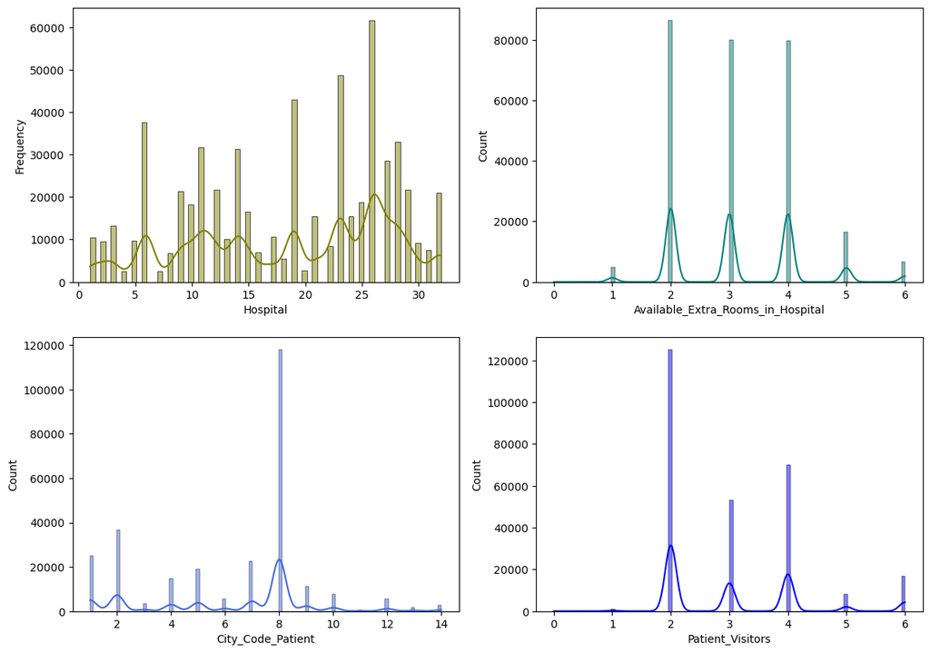

```python
# Recheck distribution for Hospital, Available_Extra_Rooms_in_Hospital, City_Code_Patient, & Patient_Visitors
fig, axes = plt.subplots(2, 2, figsize=(14, 10))

sns.histplot(hos_df4, x='Hospital', kde=True, color='olive', stat='frequency', ax=axes[0,0])
sns.histplot(hos_df4, x='Available_Extra_Rooms_in_Hospital', kde=True, color='teal', ax=axes[0,1])
sns.histplot(hos_df4, x='City_Code_Patient', kde=True, color='royalblue', ax=axes[1,0])
sns.histplot(hos_df4, x='Patient_Visitors', kde=True, color='blue', ax=axes[1,1])
plt.show()
```

After removing outliers for Available_Extra_Rooms_in_Hospital, City_Code_Patient, and Patient_Visitors, the dataset now has 274,202 instances. The distribution of these features are now less skewed, although the distributions are not normally distributed.

#### Transforming Categorical Features

**Age**: Since there are very few instances for age 91-100, this value will be combined with 81-90, combined as 81+.

```python
# Value Counts for Age:
hos_df4['Age'].value_counts()
```

```
31-40     54916
41-50     54682
51-60     41746
21-30     34951
71-80     31008
61-70     29187
11-20     14336
81-90      6899
0-10       5348
91-100     1129
Name: Age, dtype: int64
```

```python
# Proportion of each class for Age:
round(hos_df4['Age'].value_counts(normalize=True) *100,2)
```

```
31-40     20.03
41-50     19.94
51-60     15.22
21-30     12.75
71-80     11.31
61-70     10.64
11-20      5.23
81-90      2.52
0-10       1.95
91-100     0.41
Name: Age, dtype: float64
```

```python
# Replace 81-90 and 91-100, as 81+ for Age:
hos_df4['Age'] = hos_df4['Age'].replace(['81-90', '91-100'], '81+')
```

```python
# Recheck Value Counts for Age:
hos_df4['Age'].value_counts()
```

```
31-40    54916
41-50    54682
51-60    41746
21-30    34951
71-80    31008
61-70    29187
11-20    14336
81+       8028
0-10      5348
Name: Age, dtype: int64
```

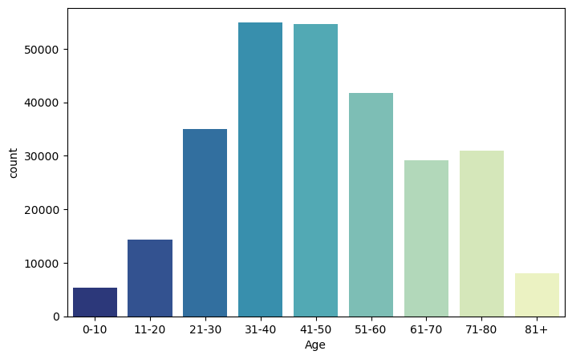

```python
# Recheck distribution for Age:
fig = plt.figure(figsize=(8, 5))
age_order = ['0-10', '11-20', '21-30', '31-40', '41-50', '51-60', '61-70', '71-80', '81+']
sns.countplot(x=hos_df4['Age'], order=age_order, palette='YlGnBu_r')
plt.show()
```

**Stay_Days**: Next, we will combine Stay_Days 41-50, 51-60, 61-70, 71-80, 81-90, 91-100, and more than 100 days as 41+ days.

```python
# Value Counts for Stay_Days:
hos_df4['Stay_Days'].value_counts()
```

```
21-30                 77902
11-20                 69498
31-40                 48098
51-60                 29599
0-10                  20703
41-50                 10137
71-80                  7849
81-90                  3221
More than 100 Days     2936
61-70                  2271
91-100                 1988
Name: Stay_Days, dtype: int64
```

```python
# Proportion of each class for Stay_Days:
round(hos_df4['Stay_Days'].value_counts(normalize=True) *100,2)
```

```
21-30                 28.41
11-20                 25.35
31-40                 17.54
51-60                 10.79
0-10                   7.55
41-50                  3.70
71-80                  2.86
81-90                  1.17
More than 100 Days     1.07
61-70                  0.83
91-100                 0.73
Name: Stay_Days, dtype: float64
```

```python
# Replace 41-50, 51-60, 61-70, 71-80, 81-90, 91-100, and more than 100 days as 41+ for Stay_Days:
hos_df4['Stay_Days'] = hos_df4['Stay_Days'].replace(['41-50', '51-60', '61-70', '71-80', '81-90', '91-100', 'More than 100 Days'], '41+')
```

```python
# Recheck Value Counts for Stay_Days:
hos_df4['Stay_Days'].value_counts()
```

```
21-30    77902
11-20    69498
41+      58001
31-40    48098
0-10     20703
Name: Stay_Days, dtype: int64
```

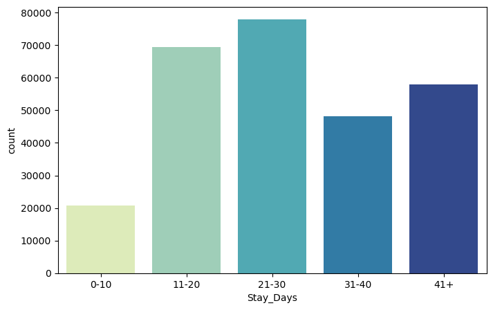

```python
# Recheck distribution for Stay_Days:
stay_order = ['0-10', '11-20', '21-30', '31-40', '41+'] #order for Stay_Days
fig = plt.figure(figsize=(8, 5)) #set fig size
sns.countplot(x=hos_df4['Stay_Days'], order=stay_order, palette='YlGnBu') #plot by order
plt.show()
```

## Set-Up & Preparation for Machine Learning

```python
# Reset Index in the DF:
hos_df4 = hos_df4.reset_index(drop=True) #reset index without adding index as a column
hos_df4 #check DF
```

|  | case_id | Hospital | Hospital_type | Hospital_city | Hospital_region | Available_Extra_Rooms_in_Hospital | Department | Ward_Type | Ward_Facility | Bed_Grade | patientid | City_Code_Patient | Type of Admission | Illness_Severity | Patient_Visitors | Age | Admission_Deposit | Stay_Days |
| --- | --- | --- | --- | --- | --- | --- | --- | --- | --- | --- | --- | --- | --- | --- | --- | --- | --- | --- |
| 0 | 1 | 8 | 2 | 3 | 2 | 3 | radiotherapy | R | F | 2.0 | 31397 | 7.0 | Emergency | Extreme | 2 | 51-60 | 4911.0 | 0-10 |
| 1 | 2 | 2 | 2 | 5 | 2 | 2 | radiotherapy | S | F | 2.0 | 31397 | 7.0 | Trauma | Extreme | 2 | 51-60 | 5954.0 | 41+ |
| 2 | 3 | 10 | 4 | 1 | 0 | 2 | anesthesia | S | E | 2.0 | 31397 | 7.0 | Trauma | Extreme | 2 | 51-60 | 4745.0 | 31-40 |
| 3 | 4 | 26 | 1 | 2 | 1 | 2 | radiotherapy | R | D | 2.0 | 31397 | 7.0 | Trauma | Extreme | 2 | 51-60 | 7272.0 | 41+ |
| 4 | 5 | 26 | 1 | 2 | 1 | 2 | radiotherapy | S | D | 2.0 | 31397 | 7.0 | Trauma | Extreme | 2 | 51-60 | 5558.0 | 41+ |
| ... | ... | ... | ... | ... | ... | ... | ... | ... | ... | ... | ... | ... | ... | ... | ... | ... | ... | ... |
| 274197 | 318433 | 26 | 1 | 2 | 1 | 2 | anesthesia | R | D | 3.0 | 36018 | 6.0 | Emergency | Minor | 3 | 11-20 | 8308.0 | 21-30 |
| 274198 | 318435 | 24 | 0 | 1 | 0 | 2 | anesthesia | Q | E | 4.0 | 325 | 8.0 | Urgent | Moderate | 4 | 81+ | 6699.0 | 31-40 |
| 274199 | 318436 | 7 | 0 | 4 | 0 | 3 | gynecology | R | F | 4.0 | 125235 | 10.0 | Emergency | Minor | 3 | 71-80 | 4235.0 | 11-20 |
| 274200 | 318437 | 11 | 1 | 2 | 1 | 3 | anesthesia | Q | D | 3.0 | 91081 | 8.0 | Trauma | Minor | 5 | 11-20 | 3761.0 | 11-20 |
| 274201 | 318438 | 19 | 0 | 7 | 1 | 5 | gynecology | Q | C | 2.0 | 21641 | 8.0 | Emergency | Minor | 2 | 11-20 | 4752.0 | 0-10 |

274202 rows × 18 columns

```python
X = hos_df4.drop(['case_id','Stay_Days', 'patientid'], axis=1) # Create DF for Features (remove case_id and Stay_Days)
y = hos_df4['Stay_Days'] # Create DF for Target
```

```python
X # View Features
```

|  | Hospital | Hospital_type | Hospital_city | Hospital_region | Available_Extra_Rooms_in_Hospital | Department | Ward_Type | Ward_Facility | Bed_Grade | City_Code_Patient | Type of Admission | Illness_Severity | Patient_Visitors | Age | Admission_Deposit |
| --- | --- | --- | --- | --- | --- | --- | --- | --- | --- | --- | --- | --- | --- | --- | --- |
| 0 | 8 | 2 | 3 | 2 | 3 | radiotherapy | R | F | 2.0 | 7.0 | Emergency | Extreme | 2 | 51-60 | 4911.0 |
| 1 | 2 | 2 | 5 | 2 | 2 | radiotherapy | S | F | 2.0 | 7.0 | Trauma | Extreme | 2 | 51-60 | 5954.0 |
| 2 | 10 | 4 | 1 | 0 | 2 | anesthesia | S | E | 2.0 | 7.0 | Trauma | Extreme | 2 | 51-60 | 4745.0 |
| 3 | 26 | 1 | 2 | 1 | 2 | radiotherapy | R | D | 2.0 | 7.0 | Trauma | Extreme | 2 | 51-60 | 7272.0 |
| 4 | 26 | 1 | 2 | 1 | 2 | radiotherapy | S | D | 2.0 | 7.0 | Trauma | Extreme | 2 | 51-60 | 5558.0 |
| ... | ... | ... | ... | ... | ... | ... | ... | ... | ... | ... | ... | ... | ... | ... | ... |
| 274197 | 26 | 1 | 2 | 1 | 2 | anesthesia | R | D | 3.0 | 6.0 | Emergency | Minor | 3 | 11-20 | 8308.0 |
| 274198 | 24 | 0 | 1 | 0 | 2 | anesthesia | Q | E | 4.0 | 8.0 | Urgent | Moderate | 4 | 81+ | 6699.0 |
| 274199 | 7 | 0 | 4 | 0 | 3 | gynecology | R | F | 4.0 | 10.0 | Emergency | Minor | 3 | 71-80 | 4235.0 |
| 274200 | 11 | 1 | 2 | 1 | 3 | anesthesia | Q | D | 3.0 | 8.0 | Trauma | Minor | 5 | 11-20 | 3761.0 |
| 274201 | 19 | 0 | 7 | 1 | 5 | gynecology | Q | C | 2.0 | 8.0 | Emergency | Minor | 2 | 11-20 | 4752.0 |

274202 rows × 15 columns

```python
y # View Target
```

```
0          0-10
1           41+
2         31-40
3           41+
4           41+
          ...
274197    21-30
274198    31-40
274199    11-20
274200    11-20
274201     0-10
Name: Stay_Days, Length: 274202, dtype: object
```

### Encoding for Categorical Features

#### Dummies for Categorical Features

Since many of the features are categorical, dummy variables will be created for each categorical feature. The following categorical features will be transformed: Department, Ward_Type, Ward_Facility, Type of Admission, Illness_Severity, and Age. There are several numeric features that are likely categorical in nature including Hospital_type, Hospital_city, Hospital_region, Bed_Grade, and City_Code_Patient. Bed_Grade is the condition of the bed which is likely ordinal as it represents a ranking of quality condition. For this analysis, these features will remain as numeric and will treated as numeric for the models. Turning these features into dummies will increase the dimensionality of the data but does not significantly increase model performance.

```python
# Specify Categorical Columns, Transform into dummy variables
cat_feats = ['Department', 'Ward_Type', 'Ward_Facility', 'Type of Admission', 'Illness_Severity', 'Age']
X_dummies = pd.get_dummies(X, columns=cat_feats, drop_first=False)
```

```python
# Check Info for Dummies DF:
X_dummies.info()
```

```
<class 'pandas.core.frame.DataFrame'>
RangeIndex: 274202 entries, 0 to 274201
Data columns (total 41 columns):
 #   Column                             Non-Null Count   Dtype
---  ------                             --------------   -----
 0   Hospital                           274202 non-null  int64
 1   Hospital_type                      274202 non-null  int64
 2   Hospital_city                      274202 non-null  int64
 3   Hospital_region                    274202 non-null  int64
 4   Available_Extra_Rooms_in_Hospital  274202 non-null  int64
 5   Bed_Grade                          274202 non-null  float64
 6   City_Code_Patient                  274202 non-null  float64
 7   Patient_Visitors                   274202 non-null  int64
 8   Admission_Deposit                  274202 non-null  float64
 9   Department_TB & Chest disease      274202 non-null  uint8
```

[output cut: 33 more lines]

Above, the dummies have been created for the categorical features and the dimensionality of the data has increased to 41 variables. The total number of rows is 274,202 and the total number of columns is 41.

#### Label Encoder for Target Variable

The target variable, Stay_Days can be considered an ordinal variable since each value represents a progression of the number of days in the hospital. Staying shorter amount of days may have diffferent implications than staying longer days. Since the target variable is ordinal, the target variable will be encoded using Label Encoder with specific order. The target variable will have 5 categories and this analysis will be a multiclass classification prediction.

```python
# Instantiate the label encoder
label_encoder = LabelEncoder()
```

```python
# Assign encoded values to y
y_T = label_encoder.fit_transform(y)
```

```python
# Review Econding for y_T
yunique = np.unique(y)
y_Tunique = np.unique(y_T)
y_encode = dict(zip(yunique, y_Tunique))
print(y_encode)
```

```
{'0-10': 0, '11-20': 1, '21-30': 2, '31-40': 3, '41+': 4}
```

```python
# View encoded y_T
y_T
```

```
array([0, 4, 3, ..., 1, 1, 0])
```

Above, the target has been transformed appropriately in ordinal order. The target will be encoded as 0-10 days: 0, 11-20 days: 1, 21-30 days: 2, 31-40 days: 3, and 41+ days: 4

### Train Test Split

```python
# Split Data into Train, Validation, and Test Sets at 70-20-10 ratio:
X_train, X_test, y_train, y_test = train_test_split(X_dummies, y_T, test_size=0.10, random_state=0)
X_train, X_val, y_train, y_val = train_test_split(X_train, y_train, test_size=0.20, random_state=0)
```

```python
X_train.shape # Check Training size
```

```
(197424, 41)
```

```python
X_val.shape # Check Validation size
```

```
(49357, 41)
```

```python
X_test.shape # Check Normalized Testing
```

```
(27421, 41)
```

```python
# Print Train Test Ratio Split
print(f"Train Ratio: {X_train.shape[0]/X.shape[0]:.2f} %")
print(f"Validation Ratio: {X_val.shape[0]/X.shape[0]:.2f} %")
print(f"Test Ratio: {X_test.shape[0]/X.shape[0]:.2f} %")
```

```
Train Ratio: 0.72 %
Validation Ratio: 0.18 %
Test Ratio: 0.10 %
```

### Min-Max Normalization

Since the features range in value, the features will be scaled. Since the majority of the features do not follow a normal distribution, the features will be scaled using Min-Max Normalization. This scaling technique shifts values and rescales to fit within a range between 0 and 1. The normalized features will be used in the Support Vector Classifier models.

```python
# Normalize Features using Min-Max Scaler
mm = MinMaxScaler()
mm.fit(X_train)
X2n_train = mm.transform(X_train)
X2n_val = mm.transform(X_val)
X2n_test = mm.transform(X_test)
```

```python
X2n_train.shape # Check Normalized Training
```

```
(197424, 41)
```

```python
X2n_val.shape # Check Normalized Validation
```

```
(49357, 41)
```

```python
X2n_test.shape # Check Normalized Testing
```

```
(27421, 41)
```

### Utility Functions

```python
# Function to Plot Validation Curve:
def plot_validation_curve(scores_params, param_name):
    plt.plot(scores_params, label='cv') #plot the scores
    plt.xticks(np.arange(len(param_name)), param_name, rotation=45) #set the x-axis ticks
    plt.xlabel(str(param_name)) #label x-axis
    plt.ylabel('Score') #label y-axis
    plt.title('Validation Curve') # set title
    plt.legend() #show legend
    plt.show() #show plot
```

```python
# Function to Fit Model, Make Prediction, and Get Scores saved as a DF:
def fit_predict_score(model, X_train, y_train, X_val, y_val): #takes as input model, X, and Y
    model.fit(X_train, y_train) #fit model with training data
    y_pred = model.predict(X_val) #predict on validation data
    acc = np.round(accuracy_score(y_val, y_pred), 4) #accuracy rounded to 4 decimals
    bal_acc = np.round(balanced_accuracy_score(y_val, y_pred), 4) #balanced accuracy rounded to 4 decimals
    scores = {'Model': [model.__class__.__name__], 'Accuracy':[acc], 'Balanced Accuracy': [bal_acc]} #place model name & scores in dict
    scores_df = pd.DataFrame(scores) #create df for scores
    return scores_df #return df
```

```python
# Function to Fit Model, Make Prediction, Display Confusion Matrix with Accuracy Score & Classification Report
def fit_predict_display_scores(model, X_train, y_train, X_val, y_val): #takes as input model, X, and Y
    model.fit(X_train, y_train) #fit model with training data
    y_pred = model.predict(X_val) #predict on validation data
    acc = np.round(accuracy_score(y_val, y_pred), 4) #accuracy rounded to 4 decimals
    metrics.ConfusionMatrixDisplay.from_predictions(y_val, y_pred) #display confusion matrix
    plt.title(str(model.__class__.__name__) + ' | ' + 'Accuracy: ' + str(acc), fontsize=12) #title confusion matrix with name of clf and acc
    plt.show() #show plot
    print(classification_report(y_val, y_pred)) #print classification reprot
```

```python
# Function that Plots Feature Importance
def plot_feature_importances(model, df):
    n_features = df.shape[1] #capture features from DF
    df_colnames= df.columns #capture feature names
    plt.barh(np.arange(n_features), model.feature_importances_, align='center', color='teal') #bar plot
    plt.yticks(np.arange(n_features), df_colnames) #set the y-ticks
    plt.xlabel("Feature Importance") #label x-axis
    plt.ylabel("Features") #label y-axis
    plt.title(str(model)) #set title
    plt.ylim(-1, n_features) #set the y-axis limits
```

```python
# Function that Predicts on a best_estimator and Displays Confusion Matrix with Accuracy Score
def fit_predict_display_bestscores(best_est, X_val, y_val): #takes as input model, X, and Y
    y_pred = best_est.predict(X_val) #predict on validation data
    acc = np.round(accuracy_score(y_val, y_pred), 4) #accuracy rounded to 4 decimals
    metrics.ConfusionMatrixDisplay.from_predictions(y_val, y_pred) #display confusion matrix
    plt.title(str(best_est.__class__.__name__) + ' | ' + 'Accuracy: ' + str(acc), fontsize=12) #title confusion matrix with name of clf and acc
    plt.show() #show plot
    print(classification_report(y_val, y_pred)) #print classification reprot
```

```python
# Function that Predicts on a best_estimator and Gets Scores saved as a DF
def fit_predict_bestscore(best_est, X_val, y_val): #takes as input model, X, and Y
    y_pred = best_est.predict(X_val) #predict on validation data
    acc = np.round(accuracy_score(y_val, y_pred), 4) #accuracy rounded to 4 decimals
    bal_acc = np.round(balanced_accuracy_score(y_val, y_pred), 4) #balanced accuracy rounded to 4 decimals
    scores = {'Model': [best_est.__class__.__name__], 'Accuracy':[acc], 'Balanced Accuracy': [bal_acc]} #place model name & scores in dict
    scores_df = pd.DataFrame(scores) #create df for scores
    return scores_df #return df
```

## Baseline Models for Training/Validation

**Tree-Based Classifiers**: Random Forest Classifier, Adaboost Classifier, and Gradient Boosting Classifier will be fitted as models. These classifiers are robust to outliers, supports non-linear and multi-class predictions, and can handle categorical features.

**Other Classifiers**: The following classifiers support multiclass prediction and will be fitted as models for comparsion: K-Nearest Neighbor Classifier, Linear Discriminant Analysis (LDA), Linear Support Vector Classifier (SVC), and Stochastic Gradient Descent (SGD) Classifier using SVC as the loss function.

```python
# Random Forest: Initialize the Random Forest Classifier w/ Default Parameters
RF = RandomForestClassifier(random_state=0, class_weight='balanced') # balanced class_weight

# GradientBoost: Initialize the Gradient Boosting Classifier w/ Default Parameters
gbst = GradientBoostingClassifier(random_state=0)

# Adaboost: Initialize the Adaboost Classifier w/ Default Parameters
AdaB = AdaBoostClassifier(random_state=0)

# KNN Classifier: Initialize the KNN Classifier w/ Default Parameters
knn = KNeighborsClassifier(n_jobs = -1)

# LDA Classifier: Initialize the LDA Classifier w/ Default Parameters
lda = LinearDiscriminantAnalysis()

# SVC Classifier: Initialize the LDA Classifier w/ Default Parameters
linSVC = LinearSVC(random_state=0, class_weight='balanced') # balanced class_weight

# SGD Classifier: Initialize the SGD Classifier w/ Default Parameters
SGD = SGDClassifier(random_state=0, n_jobs=-1, class_weight='balanced')
```

### Random Forest Classifier

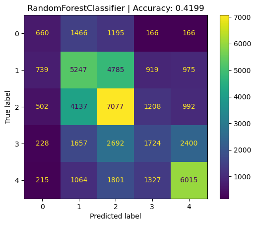

```
              precision    recall  f1-score   support

           0       0.28      0.18      0.22      3653
           1       0.39      0.41      0.40     12665
           2       0.40      0.51      0.45     13916
           3       0.32      0.20      0.25      8701
           4       0.57      0.58      0.57     10422

    accuracy                           0.42     49357
   macro avg       0.39      0.38      0.38     49357
weighted avg       0.41      0.42      0.41     49357
```

```python
# Random Forest:
RF_val = fit_predict_score(RF, X2n_train, y_train, X2n_val, y_val) # get scores as DF
fit_predict_display_scores(RF, X2n_train, y_train, X2n_val, y_val) # display  confusion matrix + score
```

### Gradient Boosting Classifier

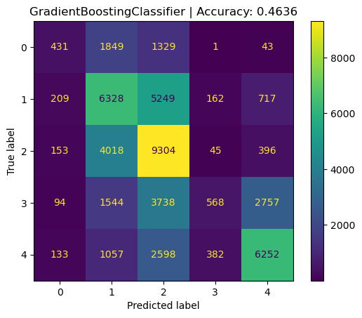

```
              precision    recall  f1-score   support

           0       0.42      0.12      0.18      3653
           1       0.43      0.50      0.46     12665
           2       0.42      0.67      0.51     13916
           3       0.49      0.07      0.12      8701
           4       0.62      0.60      0.61     10422

    accuracy                           0.46     49357
   macro avg       0.47      0.39      0.38     49357
weighted avg       0.48      0.46      0.43     49357
```

```python
# GradientBoost:
gbst_val = fit_predict_score(gbst, X2n_train, y_train, X2n_val, y_val) # get scores as DF
fit_predict_display_scores(gbst, X2n_train, y_train, X2n_val, y_val) # display  confusion matrix + score
```

### AdaBoost Classifier

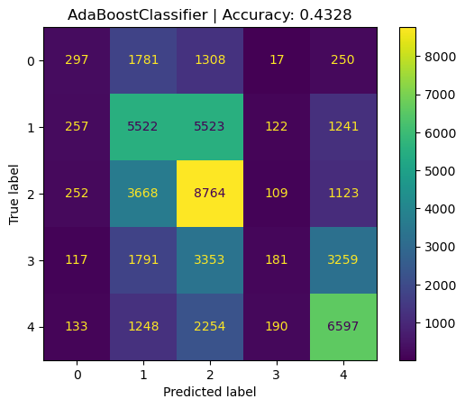

```
              precision    recall  f1-score   support

           0       0.28      0.08      0.13      3653
           1       0.39      0.44      0.41     12665
           2       0.41      0.63      0.50     13916
           3       0.29      0.02      0.04      8701
           4       0.53      0.63      0.58     10422

    accuracy                           0.43     49357
   macro avg       0.38      0.36      0.33     49357
weighted avg       0.40      0.43      0.38     49357
```

```python
# AdaBoost:
AdaB_val = fit_predict_score(AdaB, X2n_train, y_train, X2n_val, y_val) # get scores as DF
fit_predict_display_scores(AdaB, X2n_train, y_train, X2n_val, y_val) # display  confusion matrix + score
```

### KNearest Neighbor Classifier

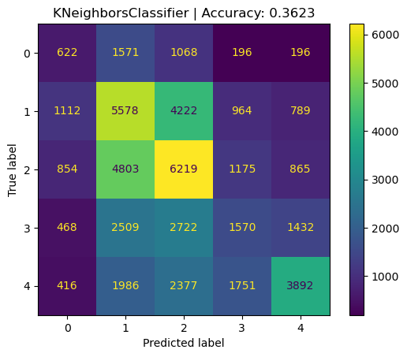

```
              precision    recall  f1-score   support

           0       0.18      0.17      0.17      3653
           1       0.34      0.44      0.38     12665
           2       0.37      0.45      0.41     13916
           3       0.28      0.18      0.22      8701
           4       0.54      0.37      0.44     10422

    accuracy                           0.36     49357
   macro avg       0.34      0.32      0.33     49357
weighted avg       0.37      0.36      0.36     49357
```

```python
# KNN:
knn_val = fit_predict_score(knn, X2n_train, y_train, X2n_val, y_val) # get scores as DF
fit_predict_display_scores(knn, X2n_train, y_train, X2n_val, y_val) # display  confusion matrix + score
```

### Linear Discriminant Analysis (LDA) Classifier

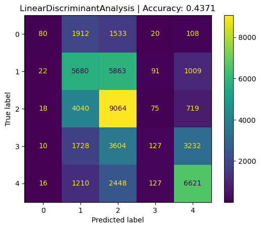

```
              precision    recall  f1-score   support

           0       0.55      0.02      0.04      3653
           1       0.39      0.45      0.42     12665
           2       0.40      0.65      0.50     13916
           3       0.29      0.01      0.03      8701
           4       0.57      0.64      0.60     10422

    accuracy                           0.44     49357
   macro avg       0.44      0.35      0.32     49357
weighted avg       0.42      0.44      0.38     49357
```

```python
# LDA:
lda_val = fit_predict_score(lda, X2n_train, y_train, X2n_val, y_val) # get scores as DF
fit_predict_display_scores(lda, X2n_train, y_train, X2n_val, y_val)  # display  confusion matrix + score
```

### Support Vector Classifier (SVC)

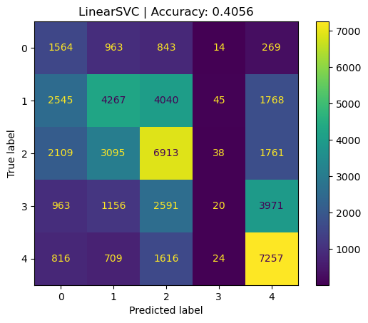

```
              precision    recall  f1-score   support

           0       0.20      0.43      0.27      3653
           1       0.42      0.34      0.37     12665
           2       0.43      0.50      0.46     13916
           3       0.14      0.00      0.00      8701
           4       0.48      0.70      0.57     10422

    accuracy                           0.41     49357
   macro avg       0.33      0.39      0.34     49357
weighted avg       0.37      0.41      0.37     49357
```

```python
# Linear SVC
linSVC_val = fit_predict_score(linSVC, X2n_train, y_train, X2n_val, y_val) # get scores as DF
fit_predict_display_scores(linSVC, X2n_train, y_train, X2n_val, y_val) # display confusion matrix + score
```

### Stochastic Gradient Descent (SGD) Classifier

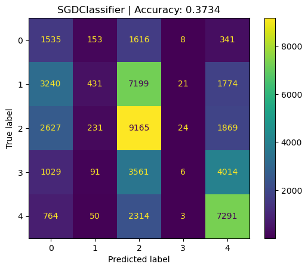

```
              precision    recall  f1-score   support

           0       0.17      0.42      0.24      3653
           1       0.45      0.03      0.06     12665
           2       0.38      0.66      0.49     13916
           3       0.10      0.00      0.00      8701
           4       0.48      0.70      0.57     10422

    accuracy                           0.37     49357
   macro avg       0.32      0.36      0.27     49357
weighted avg       0.35      0.37      0.29     49357
```

```python
# SGD
sgd_val = fit_predict_score(SGD, X2n_train, y_train, X2n_val, y_val)
fit_predict_display_scores(SGD, X2n_train, y_train, X2n_val, y_val)
```

### Results Summary for Baseline Models

```python
# Display Accuracy Results for Baseline Models
base_df = [knn_val, sgd_val, linSVC_val, RF_val, AdaB_val, lda_val, gbst_val]
base_results = pd.concat(base_df, ignore_index=True) #combine all model results
base_results
```

|  | Model | Accuracy | Balanced Accuracy |
| --- | --- | --- | --- |
| 0 | KNeighborsClassifier | 0.3623 | 0.3223 |
| 1 | SGDClassifier | 0.3734 | 0.3626 |
| 2 | LinearSVC | 0.4056 | 0.3921 |
| 3 | RandomForestClassifier | 0.4199 | 0.3758 |
| 4 | AdaBoostClassifier | 0.4328 | 0.3602 |
| 5 | LinearDiscriminantAnalysis | 0.4371 | 0.3543 |
| 6 | GradientBoostingClassifier | 0.4636 | 0.3903 |

Above, GradientBoosting Classifier performed the best with an accuracy score of **0.4636** on the validation set. LDA Classifier acheived an accuracy score of **0.4371** and AdaBoost Classifier achieved a score of **0.4328**. Random Forest achieved an accuracy score of **0.4199** and SVC Classifier achieved an accuracy score of **0.4056**. SGD Classifier and KNN Classifier did not perform as well which is expected since these classifiers perform better with numeric features. Next, hyperparameter tuning will be implemented to optimize and improve model performance.

## Optimized Models

### Hyperparameter Tuning with GridSearchCV

#### Random Forest Optimization

##### Apply GridSearchCV to find optium parameter value for max_depth

```python
# Check values for max_depth
max_depth = [1, 5, 10, 15, 20, 30]
```

```python
# Search parameter and get scores for each value
scores_params = [] #append scores
for m in max_depth: #for each value in max_depth
    RF = RandomForestClassifier(random_state=0, class_weight='balanced', max_depth=m) #initiate RF Classifier
    scores = cross_val_score(RF, X=X2n_train, y=y_train, cv=3) #get cv score using classifer
    scores_params.append(scores.mean()) #append mean score
```

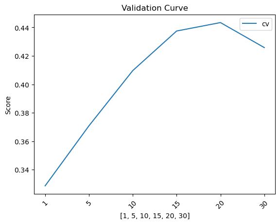

```python
# Plot Validation Curve
plot_validation_curve(scores_params, max_depth)
```

Above, the validation curve shows that the best scores occured when max_depth is between 15 and 25. Values within this range will be checked in the GridSearch.

##### Get Best Estimator from GridSearchCV with optium parameter value for max_depth

```python
# Create parameter dictionary for max_depth
RF_params = dict(
    max_depth = [15, 17, 19, 20, 21])
```

```python
# Initiate Grid Search for max_depth
gs_RF = GridSearchCV(estimator=RF, param_grid=RF_params, cv=3, n_jobs=-1)
```

```python
# Fit GridSearchCV to Training Set
gs_RF.fit(X2n_train, y_train)
```

```
GridSearchCV(cv=3,
             estimator=RandomForestClassifier(class_weight='balanced',
                                              max_depth=30, random_state=0),
             n_jobs=-1, param_grid={'max_depth': [15, 17, 19, 20, 21]})
```

```python
# Capture Best Estimator Model for RF
best_RF = gs_RF.best_estimator_ #get best estimator
best_RF_val = fit_predict_bestscore(best_RF, X2n_val, y_val) #get scores to df
best_RF #show best estimator params
```

```
RandomForestClassifier(class_weight='balanced', max_depth=19, random_state=0)
```

##### View Accuracy, Confusion Matrix, and Performance

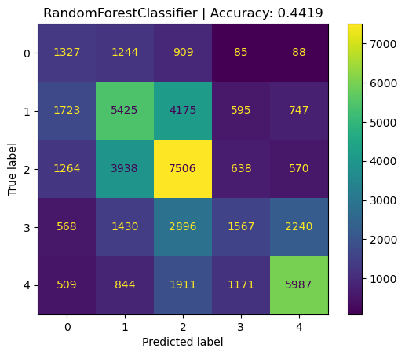

```
              precision    recall  f1-score   support

           0       0.25      0.36      0.29      3653
           1       0.42      0.43      0.42     12665
           2       0.43      0.54      0.48     13916
           3       0.39      0.18      0.25      8701
           4       0.62      0.57      0.60     10422

    accuracy                           0.44     49357
   macro avg       0.42      0.42      0.41     49357
weighted avg       0.45      0.44      0.44     49357
```

```python
# View Accuracy, Confusion Matrix, and Performance
fit_predict_display_bestscores(best_RF, X2n_val, y_val)
```

##### Plot Feature Importance for Best Estimator

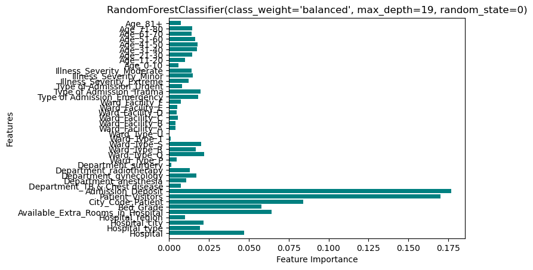

```python
# Check Feature Importance from the model:
plot_feature_importances(best_RF, X_dummies)
```

With the GridSearchCV, the best estimator for Random Forest has a max_depth=19 and achieved a validation accuracy of **0.4419**, which is an improvement from the baseline model. From the F1 scores, the model appears to be able to predict class 1, 2, and 4 better than class 0 and 3. Above, the feature importance plot shows that the most salient features are Admission Deposit, Patient Visitors, City Code Patient, Bed Grade, Available Extra Rooms in Hospital, and Hospital. These features represent the numeric features in the dataset.

#### Gradient Boost Optimization

##### Apply GridSearchCV to find optium parameter value for learning rate

```python
# Check values for learning_rate
learning_rate = [0.01, 0.1, 0.5, 1.0, 1.5]
```

```python
# Search parameter and get scores for each value
scores_params = [] #append scores
for m in learning_rate: #for each value in learning_rate
    gbst = GradientBoostingClassifier(random_state=0, learning_rate=m)
    scores = cross_val_score(gbst, X=X2n_train, y=y_train, cv=3) #get cv score using classifer
    scores_params.append(scores.mean()) #append mean score
```

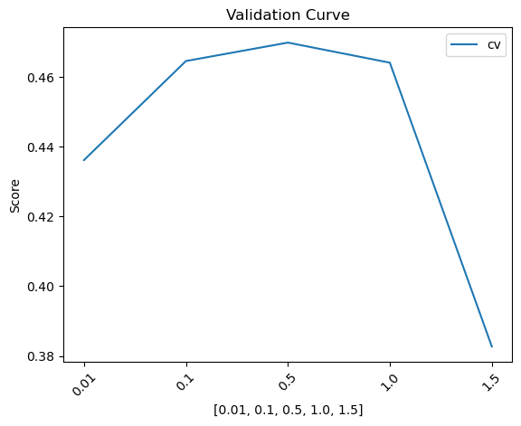

```python
# Plot Validation Curve
plot_validation_curve(scores_params, learning_rate)
```

Above, the validation curve shows that the best scores occured when the learning rate is between 0.1 and 1.0. Values within this range will be checked in the GridSearch.

##### Get Best Estimator from GridSearchCV with optium parameter value for learning rate

```python
# Create parameter dictionary for learning_rate
gbst_params = dict(
    learning_rate = [0.4, 0.5, 0.6])
```

```python
# Initiate Grid Search for learning_rate
gs_gbst = GridSearchCV(estimator=gbst, param_grid=gbst_params, cv=3, n_jobs=-1)
```

```python
# Fit GridSearchCV to Training Set
gs_gbst.fit(X2n_train, y_train)
```

```
GridSearchCV(cv=3,
             estimator=GradientBoostingClassifier(learning_rate=1.5,
                                                  random_state=0),
             n_jobs=-1, param_grid={'learning_rate': [0.4, 0.5, 0.6]})
```

```python
# Capture Best Estimator Model for gbst
best_gbst = gs_gbst.best_estimator_ #get best estimator
best_gbst_val = fit_predict_bestscore(best_gbst, X2n_val, y_val) #get scores to df
best_gbst #show best estimator params
```

```
GradientBoostingClassifier(learning_rate=0.5, random_state=0)
```

##### View Accuracy, Confusion Matrix, and Performance

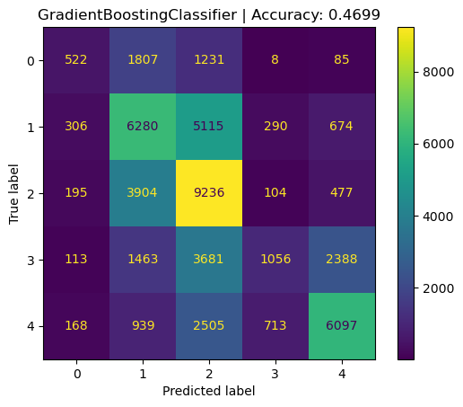

```
              precision    recall  f1-score   support

           0       0.40      0.14      0.21      3653
           1       0.44      0.50      0.46     12665
           2       0.42      0.66      0.52     13916
           3       0.49      0.12      0.19      8701
           4       0.63      0.59      0.61     10422

    accuracy                           0.47     49357
   macro avg       0.47      0.40      0.40     49357
weighted avg       0.48      0.47      0.44     49357
```

```python
# Fit, Predict Score, and Display Confusion Matrix
fit_predict_display_bestscores(best_gbst, X2n_val, y_val)
```

##### Plot Feature Importance for Best Estimator

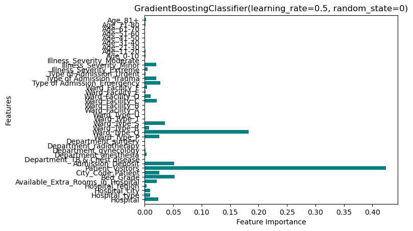

```python
# Check Feature Importance from the model:
plot_feature_importances(best_gbst, X_dummies)
```

With the GridSearchCV, the best estimator for GradientBoost has a learning rate=0.5 and achieved a validation accuracy of **0.4699**, which is an improvement from the baseline model. From the F1 scores, similar to the Random Forest model, this model also appears to be able to predict class 1, 2, and 4 better than class 0 and 3. Above, the feature importance plot shows that the most salient features are Patient Visitors and Ward_Type. Compared to the Random Forest model, this model has very distinct salient features and is more interpretable.

#### AdaBoost Optimization

##### Apply GridSearchCV to find optium parameter value for learning rate

```python
# Check values for learning_rate
learning_rate = [0.1, 0.5, 0.7, 1.0, 1.5, 2.0]
```

```python
# Search parameter and get scores for each value
scores_params = [] #append scores
for m in learning_rate: #for each value in learning_rate
    AdaB = AdaBoostClassifier(random_state=0, learning_rate=m)
    scores = cross_val_score(AdaB, X=X2n_train, y=y_train, cv=3) #get cv score using classifer
    scores_params.append(scores.mean()) #append mean score
```

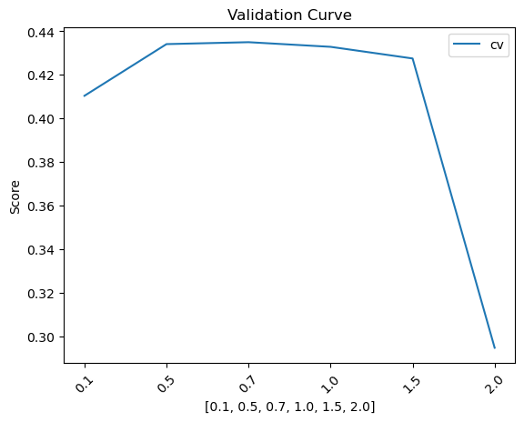

```python
# Plot Validation Curve
plot_validation_curve(scores_params, learning_rate)
```

Above, the validation curve shows that the best scores occured when the learning rate is between 0.5 and 1.0. Values within this range will be checked in the GridSearch.

##### Get Best Estimator from GridSearchCV with optium parameter value for learning rate

```python
# Create parameter dictionary for learning_rate
ada_params = dict(
    learning_rate = [0.5, 0.6, 0.7, 0.8, 1.0])
```

```python
# Initiate Grid Search for learning_rate
gs_ada = GridSearchCV(estimator=AdaB, param_grid=ada_params, cv=3, n_jobs=-1)
```

```python
# Fit GridSearchCV to Training Set
gs_ada.fit(X2n_train, y_train)
```

```
GridSearchCV(cv=3,
             estimator=AdaBoostClassifier(learning_rate=2.0, random_state=0),
             n_jobs=-1,
             param_grid={'learning_rate': [0.5, 0.6, 0.7, 0.8, 1.0]})
```

```python
# Capture Best Estimator Model for AdaBoost
best_ada = gs_ada.best_estimator_
best_ada_val = fit_predict_bestscore(best_ada, X2n_val, y_val)
best_ada
```

```
AdaBoostClassifier(learning_rate=0.7, random_state=0)
```

##### View Accuracy, Confusion Matrix, and Performance

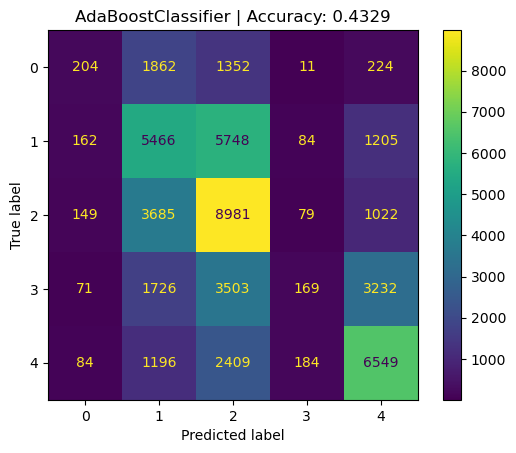

```
              precision    recall  f1-score   support

           0       0.30      0.06      0.09      3653
           1       0.39      0.43      0.41     12665
           2       0.41      0.65      0.50     13916
           3       0.32      0.02      0.04      8701
           4       0.54      0.63      0.58     10422

    accuracy                           0.43     49357
   macro avg       0.39      0.36      0.32     49357
weighted avg       0.41      0.43      0.38     49357
```

```python
# View Accuracy, Confusion Matrix, and Performance
fit_predict_display_bestscores(best_ada, X2n_val, y_val)
```

##### Plot Feature Importance for Best Estimator

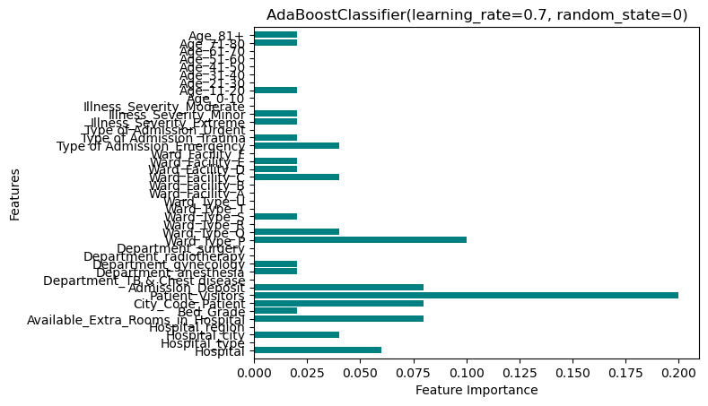

```python
# Check Feature Importance from the model:
plot_feature_importances(best_ada, X_dummies)
```

### Extended Models

Since GradientBoost and LDA classifiers performed well, enhanced versions of these models will be explored. An extended version of Gradient Boosting Classifier is Histogram-Based Gradient Boosting Classiifer which is an ensemble tree method where the trainin of the trees is accelerated by discretizing (binning) the continuous input features to a certain number of unique values. This method works well with large datasets and can handle high number of categorical features. An extended version of LDA Classifier is Quadratic Discriminant Analysis (QDA) which uses a qudratic decision surface to seperate measurements of two or more classes instead of a linear decision surface. QDA assumes that each class has its own covariance matrix and is generally more flexible compared to LDA.

#### Histogram-Based Gradient Boost

##### Apply GridSearchCV to find optium parameter value for learning rate

```python
# Check values for learning_rate
learning_rate = [0.01, 0.1, 0.5, 1.0, 1.5]
```

```python
# Search parameter and get scores for each value
scores_params = [] #append scores
for m in learning_rate: #for each value in learning_rate
    hgbst = HistGradientBoostingClassifier(random_state=0, learning_rate=m)
    scores = cross_val_score(hgbst, X=X2n_train, y=y_train, cv=3) #get cv score using classifer
    scores_params.append(scores.mean()) #append mean score
```

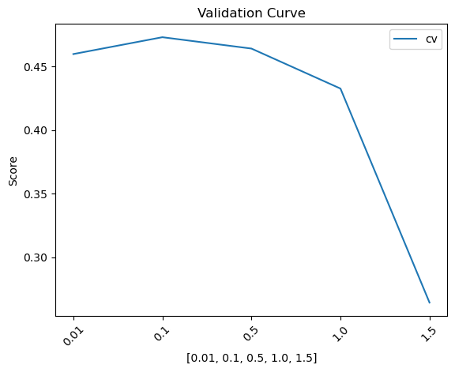

```python
# Plot Validation Curve
plot_validation_curve(scores_params, learning_rate)
```

Above, the validation curve shows that the best scores occured when the learning rate is between 0.01 and 0.1. Values within this range will be checked in the GridSearch.

##### Get Best Estimator from GridSearchCV with optium parameter value for learning_rate

```python
# Create parameter dictionary for learning_rate
hgbst_params = dict(
    learning_rate = [0.03, 0.05, 0.09, 0.1, 0.15])
```

```python
# Initiate Grid Search for learning_rate
hgbst = HistGradientBoostingClassifier(random_state=0)
gs_hgbst = GridSearchCV(estimator=hgbst, param_grid=hgbst_params, cv=3, n_jobs=-1)
```

```python
# Fit GridSearchCV to Training Set
gs_hgbst.fit(X2n_train, y_train)
```

```
GridSearchCV(cv=3, estimator=HistGradientBoostingClassifier(random_state=0),
             n_jobs=-1,
             param_grid={'learning_rate': [0.03, 0.05, 0.09, 0.1, 0.15]})
```

```python
# Capture Best Estimator Model for HistGboost
best_hgbst = gs_hgbst.best_estimator_
best_hgbst_val = fit_predict_bestscore(best_hgbst, X2n_val, y_val)
best_hgbst
```

```
HistGradientBoostingClassifier(learning_rate=0.09, random_state=0)
```

##### View Accuracy, Confusion Matrix, and Performance

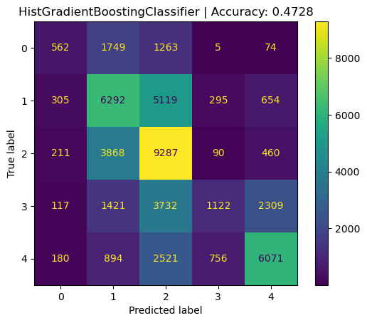

```
              precision    recall  f1-score   support

           0       0.41      0.15      0.22      3653
           1       0.44      0.50      0.47     12665
           2       0.42      0.67      0.52     13916
           3       0.49      0.13      0.20      8701
           4       0.63      0.58      0.61     10422

    accuracy                           0.47     49357
   macro avg       0.48      0.41      0.40     49357
weighted avg       0.48      0.47      0.45     49357
```

```python
# View Accuracy, Confusion Matrix, and Performance
fit_predict_display_bestscores(best_hgbst, X2n_val, y_val)
```

#### Quadratic Discriminant Analysis (QDA)

##### Apply GridSearchCV to find optium parameter value for reg_param

```python
# Check values for reg_param
reg_param = [0.0, 0.2, 0.5, 0.7, 1.0, 1.2, 1.5, 1.7, 2.0]
```

```python
# Search parameter and get scores for each value
scores_params = [] #append scores
for m in reg_param: #for each value in learning_rate
    QDA = QuadraticDiscriminantAnalysis(reg_param=m)
    scores = cross_val_score(QDA, X=X2n_train, y=y_train, cv=3) #get cv score using classifer
    scores_params.append(scores.mean()) #append mean score
```

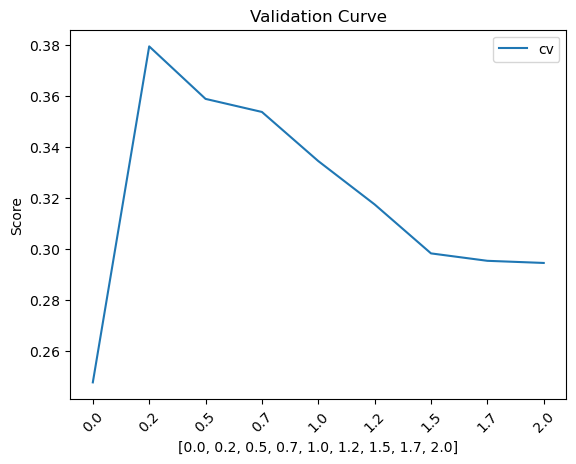

```python
# Plot Validation Curve
plot_validation_curve(scores_params, reg_param)
```

Above, the validation curve shows that the best scores occured when reg_param is between 0.1 and 0.5. Values within this range will be checked in the GridSearch.

##### Get Best Estimator from GridSearchCV with optium parameter value for reg_param

```python
# Create parameter dictionary for reg_param
qda_params = dict(
    reg_param = [0.1, 0.15, 0.2, 0.25, 0.3])
```

```python
# Initiate Grid Search for reg_param
QDA = QuadraticDiscriminantAnalysis()
gs_qda = GridSearchCV(estimator=QDA, param_grid=qda_params, cv=3, n_jobs=-1)
```

```python
# Fit GridSearchCV to Training Set
gs_qda.fit(X2n_train, y_train)
```

```
GridSearchCV(cv=3, estimator=QuadraticDiscriminantAnalysis(), n_jobs=-1,
             param_grid={'reg_param': [0.1, 0.15, 0.2, 0.25, 0.3]})
```

```python
# Capture Best Estimator Model for QDA
best_qda = gs_qda.best_estimator_
best_qda_val = fit_predict_bestscore(best_qda, X2n_val, y_val)
best_qda
```

```
QuadraticDiscriminantAnalysis(reg_param=0.1)
```

##### View Accuracy, Confusion Matrix, and Performance

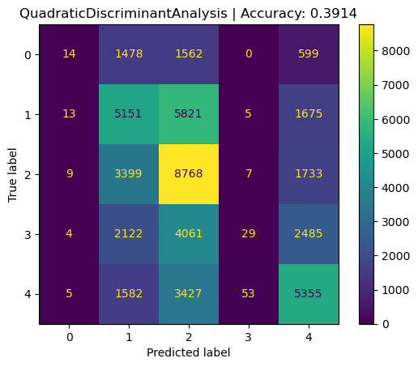

```
              precision    recall  f1-score   support

           0       0.31      0.00      0.01      3653
           1       0.38      0.41      0.39     12665
           2       0.37      0.63      0.47     13916
           3       0.31      0.00      0.01      8701
           4       0.45      0.51      0.48     10422

    accuracy                           0.39     49357
   macro avg       0.36      0.31      0.27     49357
weighted avg       0.37      0.39      0.34     49357
```

```python
# View Accuracy, Confusion Matrix, and Performance
fit_predict_display_bestscores(best_qda, X2n_val, y_val)
```

With the GridSearchCV, the best estimator for QDA has a reg_param=0.1 and achieved a validation accuracy of **0.3914**, which is significantly lower than the accuracy score achieved from the LDA model. Similar to the LDA model, this model is unable to predict class 0 and 3, in which f1 scores for these two classes are extremely low at 0.01.

### Results Summary for Optimized Models

```python
# Display Accuracy Results for Optimized Models
optimized_df = [best_qda_val, best_ada_val, best_RF_val, best_gbst_val, best_hgbst_val]
optimized_results = pd.concat(optimized_df, ignore_index=True) #combine all model results
optimized_results
```

|  | Model | Accuracy | Balanced Accuracy |
| --- | --- | --- | --- |
| 0 | QuadraticDiscriminantAnalysis | 0.3914 | 0.3116 |
| 1 | AdaBoostClassifier | 0.4329 | 0.3561 |
| 2 | RandomForestClassifier | 0.4419 | 0.4171 |
| 3 | GradientBoostingClassifier | 0.4699 | 0.4018 |
| 4 | HistGradientBoostingClassifier | 0.4728 | 0.4059 |

Above, when comparing the optimized models, the Histogram-Based Gradient Boosting model performed the best with an accuracy score of **0.4728** on the validation set. Quadratic Discriminant Analysis (QDA) performed the worst with an accuracy score of 0.3914. The model with the highest balanced accuracy score is Random Forest, which improved its performance over baseline model and performed slightly better than AdaBoost. All of the models were able to predict class 1, 2, and 4 better than class 0 and 3 as shown in their respective f1 scores. In terms of speed and efficiency, the Histogram-Based Gradient Boosting model was most efficient whereas the Gradient Boosting model was the slowest and had the most computation time.